# Parametric bootstrap for mixed-effects models

Author

Phillip Alday, Douglas Bates, and Reinhold Kliegl

Published

2025-05-13

The speed of MixedModels.jl relative to its predecessors makes the parametric bootstrap much more computationally tractable. This is valuable because the parametric bootstrap can be used to produce more accurate confidence intervals than methods based on standard errors or profiling of the likelihood surface.

This page is adapted from the [MixedModels.jl docs](https://juliastats.org/MixedModels.jl/v4/bootstrap/)

# 1 The parametric bootstrap

Bootstrapping is a family of procedures for generating sample values of a statistic, allowing for visualization of the distribution of the statistic or for inference from this sample of values. Bootstrapping also belongs to a larger family of procedures called *resampling*, which are based on creating new samples of data from an existing one, then computing statistics on the new samples, in order to examine the distribution of the relevant statistics.

A *parametric bootstrap* is used with a parametric model, `m`, that has been fit to data. The procedure is to simulate `n` response vectors from `m` using the estimated parameter values and refit `m` to these responses in turn, accumulating the statistics of interest at each iteration.

The parameters of a `LinearMixedModel` object are the fixed-effects parameters (`β`), the standard deviation (`σ`), of the per-observation noise, and the covariance parameter (`θ`), that defines the variance-covariance matrices of the random effects. A technical description of the covariance parameter can be found in the [MixedModels.jl docs](https://juliastats.org/MixedModels.jl/v4.7.1/optimization/). Lisa Schwetlick and Daniel Backhaus have provided a more beginner-friendly description of the covariance parameter in the [documentation for MixedModelsSim.jl](https://repsychling.github.io/MixedModelsSim.jl/v0.2.6/simulation_tutorial/). For today’s purposes – looking at the uncertainty in the estimates from a fitted model – we can simply use values from the fitted model, but we will revisit the parametric bootstrap as a convenient way to simulate new data, potentially with different parameter values, for power analysis.

Attach the packages to be used

```julia
using AlgebraOfGraphics
using CairoMakie
using DataFrames
using MixedModels
using MixedModelsMakie
using Random
using SMLP2025: dataset

using AlgebraOfGraphics: AlgebraOfGraphics as AoG
const progress=false
```

Note that the precise stream of random numbers generated for a given seed can change between Julia versions. For exact reproducibility, you either need to have the exact same Julia version or use the [StableRNGs](https://github.com/JuliaRandom/StableRNGs.jl) package.

# 2 A model of moderate complexity

The `kb07` data (Kronmüller & Barr, 2007) are one of the datasets provided by the `MixedModels` package.

```julia
kb07 = dataset(:kb07)
```

```
Arrow.Table with 1789 rows, 7 columns, and schema:
 :subj      String
 :item      String
 :spkr      String
 :prec      String
 :load      String
 :rt_trunc  Int16
 :rt_raw    Int16
```

Convert the table to a DataFrame for summary.

```julia
kb07 = DataFrame(kb07)
describe(kb07)
```

7×7 DataFrame

| Row | variable Symbol | mean Union… | min Any | median Union… | max Any | nmissing Int64 | eltype DataType |
| --- | --- | --- | --- | --- | --- | --- | --- |
| 1 | subj |  | S030 |  | S103 | 0 | String |
| 2 | item |  | I01 |  | I32 | 0 | String |
| 3 | spkr |  | new |  | old | 0 | String |
| 4 | prec |  | break |  | maintain | 0 | String |
| 5 | load |  | no |  | yes | 0 | String |
| 6 | rt_trunc | 2182.2 | 579 | 1940.0 | 5171 | 0 | Int16 |
| 7 | rt_raw | 2226.24 | 579 | 1940.0 | 15923 | 0 | Int16 |

The experimental factors; `spkr`, `prec`, and `load`, are two-level factors.

```julia
contrasts = Dict(:spkr => EffectsCoding(),
                 :prec => EffectsCoding(),
                 :load => EffectsCoding(),
)
```

The `EffectsCoding` contrast is used with these to create a ±1 encoding.

We can look at an initial fit of moderate complexity:

```julia
form = @formula(rt_trunc ~ 1 + spkr * prec * load +
                          (1 + spkr + prec + load | subj) +
                          (1 + spkr + prec + load | item))
m0 = fit(MixedModel, form, kb07; contrasts, progress)
```

|  | Est. | SE | z | p | σ_subj | σ_item |
| --- | --- | --- | --- | --- | --- | --- |
| (Intercept) | 2181.6729 | 77.3131 | 28.22 | <1e-99 | 301.6736 | 362.3182 |
| spkr: old | 67.7490 | 18.2747 | 3.71 | 0.0002 | 42.5441 | 40.7073 |
| prec: maintain | -333.9206 | 47.1388 | -7.08 | <1e-11 | 61.9978 | 246.8078 |
| load: yes | 78.7702 | 19.5387 | 4.03 | <1e-04 | 64.9874 | 42.5139 |
| spkr: old & prec: maintain | -21.9655 | 15.8070 | -1.39 | 0.1646 |  |  |
| spkr: old & load: yes | 18.3838 | 15.8070 | 1.16 | 0.2448 |  |  |
| prec: maintain & load: yes | 4.5333 | 15.8070 | 0.29 | 0.7743 |  |  |
| spkr: old & prec: maintain & load: yes | 23.6072 | 15.8070 | 1.49 | 0.1353 |  |  |
| Residual | 668.5371 |  |  |  |  |  |

The default display in Quarto uses the [pretty MIME show method](https://juliastats.org/MixedModels.jl/v4.7.1/mime/) for the model and omits the estimated correlations of the random effects.

The `VarCorr` extractor displays these.

```julia
VarCorr(m0)
```

|  | Column | Variance | Std.Dev | Corr. |  |  |
| --- | --- | --- | --- | --- | --- | --- |
| subj | (Intercept) | 91006.9887 | 301.6736 |  |  |  |
|  | spkr: old | 1810.0012 | 42.5441 | +0.79 |  |  |
|  | prec: maintain | 3843.7268 | 61.9978 | -0.59 | +0.02 |  |
|  | load: yes | 4223.3647 | 64.9874 | +0.36 | +0.85 | +0.54 |
| item | (Intercept) | 131274.4558 | 362.3182 |  |  |  |
|  | spkr: old | 1657.0830 | 40.7073 | +0.44 |  |  |
|  | prec: maintain | 60914.1141 | 246.8078 | -0.69 | +0.35 |  |
|  | load: yes | 1807.4303 | 42.5139 | +0.32 | +0.15 | -0.14 |
| Residual |  | 446941.7901 | 668.5371 |  |  |  |

None of the two-factor or three-factor interaction terms in the fixed-effects are significant. In the random-effects terms only the scalar random effects and the `prec` random effect for `item` appear to be warranted, leading to the reduced formula

```julia
# formula f4 from https://doi.org/10.33016/nextjournal.100002
form = @formula(rt_trunc ~ 1 + spkr * prec * load + (1 | subj) + (1 + prec | item))

m1 = fit(MixedModel, form, kb07; contrasts, progress)
```

|  | Est. | SE | z | p | σ_item | σ_subj |
| --- | --- | --- | --- | --- | --- | --- |
| (Intercept) | 2181.7582 | 77.4709 | 28.16 | <1e-99 | 364.7286 | 298.1109 |
| spkr: old | 67.8114 | 16.0526 | 4.22 | <1e-04 |  |  |
| prec: maintain | -333.8582 | 47.4629 | -7.03 | <1e-11 | 252.6687 |  |
| load: yes | 78.6849 | 16.0525 | 4.90 | <1e-06 |  |  |
| spkr: old & prec: maintain | -21.8802 | 16.0525 | -1.36 | 0.1729 |  |  |
| spkr: old & load: yes | 18.3214 | 16.0526 | 1.14 | 0.2537 |  |  |
| prec: maintain & load: yes | 4.4710 | 16.0526 | 0.28 | 0.7806 |  |  |
| spkr: old & prec: maintain & load: yes | 23.5219 | 16.0525 | 1.47 | 0.1428 |  |  |
| Residual | 678.9318 |  |  |  |  |  |

```julia
VarCorr(m1)
```

|  | Column | Variance | Std.Dev | Corr. |
| --- | --- | --- | --- | --- |
| item | (Intercept) | 133026.918 | 364.729 |  |
|  | prec: maintain | 63841.496 | 252.669 | -0.70 |
| subj | (Intercept) | 88870.080 | 298.111 |  |
| Residual |  | 460948.432 | 678.932 |  |

These two models are nested and can be compared with a likelihood-ratio test.

```julia
MixedModels.likelihoodratiotest(m0, m1)
```

|  | model-dof | deviance | χ² | χ²-dof | P(>χ²) |
| --- | --- | --- | --- | --- | --- |
| rt_trunc ~ 1 + spkr + prec + load + spkr & prec + spkr & load + prec & load + spkr & prec & load + (1 \| subj) + (1 + prec \| item) | 13 | 28658 |  |  |  |
| rt_trunc ~ 1 + spkr + prec + load + spkr & prec + spkr & load + prec & load + spkr & prec & load + (1 + spkr + prec + load \| subj) + (1 + spkr + prec + load \| item) | 29 | 28637 | 21 | 16 | 0.1650 |

# 3 Bootstrap basics

To bootstrap the model parameters, first initialize a random number generator then create a bootstrap sample and extract the table of parameter estimates from it.

```julia
const RNG = MersenneTwister(42)
samp = parametricbootstrap(RNG, 5_000, m1)
tbl = samp.tbl
```

```
Table with 18 columns and 5000 rows:
      obj      β1       β2       β3        β4       β5        β6        ⋯
    ┌────────────────────────────────────────────────────────────────────
 1  │ 28666.6  2173.04  55.6593  -359.246  87.1657  -35.2652  32.9777   ⋯
 2  │ 28709.1  1973.88  88.8108  -313.755  83.8083  -23.2173  -15.9147  ⋯
 3  │ 28575.8  2167.28  48.2509  -297.175  79.0748  -22.07    41.8946   ⋯
 4  │ 28721.3  2259.36  65.9821  -386.726  82.7248  -35.3908  14.3295   ⋯
 5  │ 28590.9  2182.95  45.0315  -410.478  109.293  -19.132   42.9369   ⋯
 6  │ 28518.9  2167.98  61.0523  -360.56   75.7268  15.1612   61.9125   ⋯
 7  │ 28702.9  2210.25  70.8323  -349.703  99.4985  -32.9348  16.797    ⋯
 8  │ 28726.1  2235.04  59.248   -353.737  58.0711  -35.2804  10.0765   ⋯
 9  │ 28734.7  2042.97  72.1467  -300.829  71.2183  -14.2944  10.7301   ⋯
 10 │ 28609.2  2011.1   76.404   -254.606  63.9238  -37.8758  3.95621   ⋯
 11 │ 28636.7  2166.35  71.1184  -324.401  58.5484  -21.7266  -31.4973  ⋯
 12 │ 28659.2  2158.36  64.3944  -336.452  80.3281  -39.3608  1.96649   ⋯
 13 │ 28637.3  2147.09  70.6536  -399.734  60.0463  -35.6682  28.4599   ⋯
 14 │ 28672.7  2138.23  75.4572  -262.36   96.9987  -32.0501  26.9257   ⋯
 15 │ 28662.5  2239.34  65.1886  -373.371  83.4639  -29.7632  5.43283   ⋯
 16 │ 28604.9  2088.54  62.0142  -268.106  99.684   -27.3686  49.5337   ⋯
 17 │ 28539.6  2313.47  61.1166  -337.951  74.769   -14.5982  48.7173   ⋯
 ⋮  │    ⋮        ⋮        ⋮        ⋮         ⋮        ⋮         ⋮      ⋱
```

An empirical density plot of the estimates of the residual standard deviation is obtained as

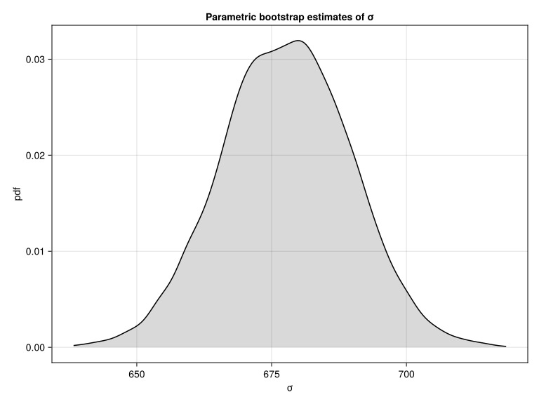

```julia
plt = data(tbl) * mapping(:σ) * AoG.density()
draw(plt; axis=(;title="Parametric bootstrap estimates of σ"))
```

A density plot of the estimates of the standard deviation of the random effects is obtained as

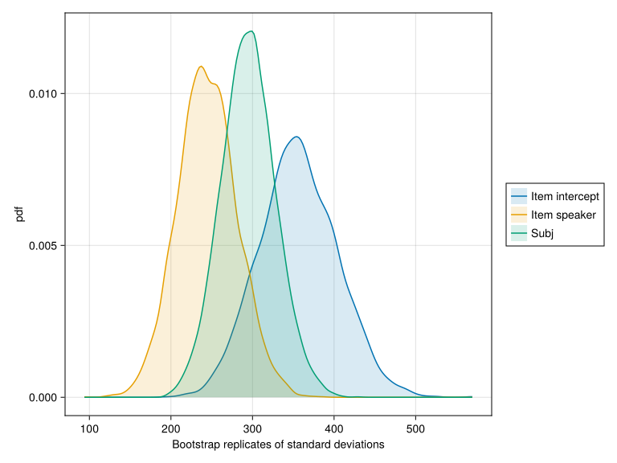

```julia
plt = data(tbl) * mapping(
  [:σ1, :σ2, :σ3] .=> "Bootstrap replicates of standard deviations";
  color=dims(1) => renamer(["Item intercept", "Item speaker", "Subj"])
) * AoG.density()
draw(plt; figure=(;supertitle="Parametric bootstrap estimates of variance components"))
```

The bootstrap sample can be used to generate intervals that cover a certain percentage of the bootstrapped values. We refer to these as “coverage intervals”, similar to a confidence interval. The shortest such intervals, obtained with the `confint` extractor, correspond to a highest posterior density interval in Bayesian inference.

We generate these for all random and fixed effects:

```julia
confint(samp; method=:shortest)
```

```
DictTable with 2 columns and 13 rows:
 par   lower      upper
 ────┬─────────────────────
 β1  │ 2033.36    2332.44
 β2  │ 34.9886    98.421
 β3  │ -430.861   -246.169
 β4  │ 48.9002    112.424
 β5  │ -51.4927   12.1684
 β6  │ -13.6705   49.681
 β7  │ -27.2138   34.6244
 β8  │ -6.36896   55.7056
 ρ1  │ -0.899979  -0.460383
 σ   │ 654.51     700.692
 σ1  │ 264.114    448.733
 σ2  │ 174.044    316.132
 σ3  │ 228.265    359.429
```

[output not shown]

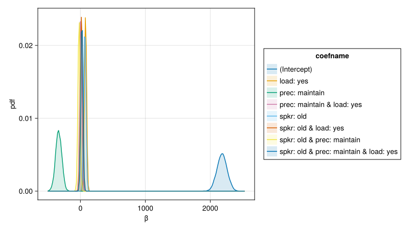

```julia
draw(
  data(samp.β) * mapping(:β; color=:coefname) * AoG.density();
  figure=(; resolution=(800, 450)),
)
```

For the fixed effects, MixedModelsMakie provides a convenience interface to plot the combined coverage intervals and density plots

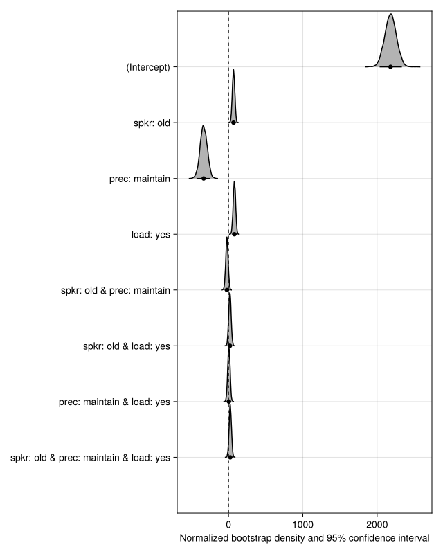

```julia
ridgeplot(samp)
```

Often the intercept will be on a different scale and potentially less interesting, so we can stop it from being included in the plot:

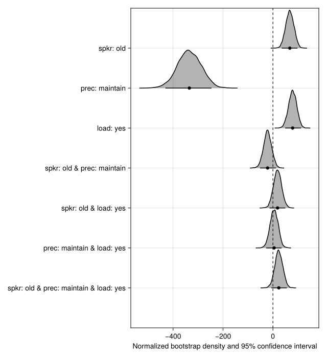

```julia
ridgeplot(samp; show_intercept=false)
```

# 4 Singularity

Let’s consider the classic dysetuff dataset:

```julia
dyestuff = dataset(:dyestuff)
mdye = fit(MixedModel, @formula(yield ~ 1 + (1 | batch)), dyestuff)
```

|  | Est. | SE | z | p | σ_batch |
| --- | --- | --- | --- | --- | --- |
| (Intercept) | 1527.5000 | 17.6946 | 86.33 | <1e-99 | 37.2603 |
| Residual | 49.5101 |  |  |  |  |

```julia
sampdye = parametricbootstrap(MersenneTwister(1234321), 10_000, mdye)
tbldye = sampdye.tbl
```

```
Table with 5 columns and 10000 rows:
      obj      β1       σ        σ1       θ1
    ┌─────────────────────────────────────────────
 1  │ 316.738  1528.14  43.5735  22.6691  0.520249
 2  │ 336.101  1552.01  58.1535  39.5166  0.679521
 3  │ 322.046  1501.55  51.857   0.0      0.0
 4  │ 326.893  1525.24  43.6512  66.3744  1.52056
 5  │ 331.544  1522.05  50.7415  51.0074  1.00524
 6  │ 326.892  1550.23  53.5174  19.0928  0.356759
 7  │ 313.786  1504.16  45.1878  0.0      0.0
 8  │ 322.636  1494.05  49.8556  17.7732  0.356494
 9  │ 323.582  1529.74  46.4678  35.2094  0.757716
 10 │ 321.639  1532.6   45.3573  32.4904  0.71632
 11 │ 331.565  1548.25  55.8562  28.7512  0.514736
 12 │ 310.076  1481.8   34.9418  38.4381  1.10006
 13 │ 314.492  1541.95  40.3751  28.3694  0.702646
 14 │ 340.876  1530.48  63.006   42.6409  0.676776
 15 │ 309.778  1496.17  41.5411  8.08346  0.19459
 16 │ 335.375  1530.32  57.4864  38.9066  0.676797
 17 │ 318.347  1511.28  41.0926  39.1128  0.951821
 ⋮  │    ⋮        ⋮        ⋮        ⋮        ⋮
```

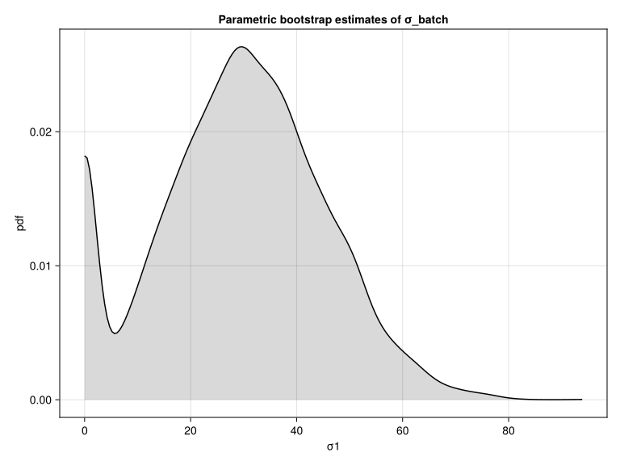

```julia
plt = data(tbldye) * mapping(:σ1) * AoG.density()
draw(plt; axis=(;title="Parametric bootstrap estimates of σ_batch"))
```

Notice that this density plot has a spike, or mode, at zero. Although this mode appears to be diffuse, this is an artifact of the way that density plots are created. In fact, it is a pulse, as can be seen from a histogram.

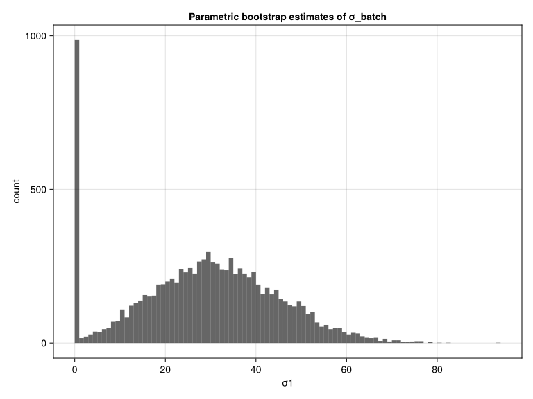

```julia
plt = data(tbldye) * mapping(:σ1) * AoG.histogram(;bins=100)
draw(plt; axis=(;title="Parametric bootstrap estimates of σ_batch"))
```

A value of zero for the standard deviation of the random effects is an example of a *singular* covariance. It is easy to detect the singularity in the case of a scalar random-effects term. However, it is not as straightforward to detect singularity in vector-valued random-effects terms.

For example, if we bootstrap a model fit to the `sleepstudy` data

```julia
sleepstudy = dataset(:sleepstudy)
msleep = fit(MixedModel, @formula(reaction ~ 1 + days + (1 + days | subj)),
             sleepstudy)
```

|  | Est. | SE | z | p | σ_subj |
| --- | --- | --- | --- | --- | --- |
| (Intercept) | 251.4051 | 6.6323 | 37.91 | <1e-99 | 23.7805 |
| days | 10.4673 | 1.5022 | 6.97 | <1e-11 | 5.7168 |
| Residual | 25.5918 |  |  |  |  |

```julia
sampsleep = parametricbootstrap(MersenneTwister(666), 10_000, msleep)
tblsleep = sampsleep.tbl
```

```
Table with 10 columns and 10000 rows:
      obj      β1       β2       σ        σ1       σ2       ρ1           ⋯
    ┌─────────────────────────────────────────────────────────────────────
 1  │ 1694.07  258.109  10.7928  22.1713  13.6388  5.42872  0.430499     ⋯
 2  │ 1731.59  241.267  9.77434  23.5943  23.882   7.07979  -0.277561    ⋯
 3  │ 1706.51  254.403  10.6731  23.0742  21.4346  3.78782  0.493345     ⋯
 4  │ 1737.33  257.833  7.61745  24.5028  27.2647  4.8567   -0.0190962   ⋯
 5  │ 1764.5   244.154  13.0045  25.8322  30.9873  7.78254  -0.532286    ⋯
 6  │ 1730.85  247.672  13.2977  24.3584  18.6105  5.87738  -0.0535883   ⋯
 7  │ 1709.66  256.847  8.60197  22.4272  26.8884  6.62183  -0.638036    ⋯
 8  │ 1776.49  252.028  9.56225  27.3708  27.7002  6.53333  -0.353783    ⋯
 9  │ 1732.12  248.687  11.5173  23.7153  22.2865  6.69781  0.304236     ⋯
 10 │ 1748.89  249.387  10.2581  25.3961  24.7505  5.44654  0.00471327   ⋯
 11 │ 1735.34  247.16   8.57302  25.593   19.2151  3.99188  1.0          ⋯
 12 │ 1757.34  248.074  9.76959  25.9834  29.2859  4.74129  0.216426     ⋯
 13 │ 1727.32  248.007  12.8942  23.9314  32.1774  3.50451  0.152022     ⋯
 14 │ 1753.38  252.684  9.88845  25.2124  21.3446  7.64867  -0.00704067  ⋯
 15 │ 1731.05  262.218  7.70815  25.0737  18.1155  4.89347  -0.280397    ⋯
 16 │ 1742.68  252.273  12.7376  24.4489  20.6843  7.47369  0.0242807    ⋯
 17 │ 1727.37  243.956  12.107   24.6337  26.502   3.89643  -0.411438    ⋯
 ⋮  │    ⋮        ⋮        ⋮        ⋮        ⋮        ⋮          ⋮       ⋱
```

the singularity can be exhibited as a standard deviation of zero or as a correlation of ±1.

```julia
confint(sampsleep)
```

```
DictTable with 2 columns and 6 rows:
 par   lower      upper
 ────┬───────────────────
 β1  │ 238.265    264.28
 β2  │ 7.56525    13.4072
 ρ1  │ -0.409958  1.0
 σ   │ 22.6673    28.5759
 σ1  │ 10.5606    33.2568
 σ2  │ 3.08374    7.73233
```

A histogram of the estimated correlations from the bootstrap sample has a spike at `+1`.

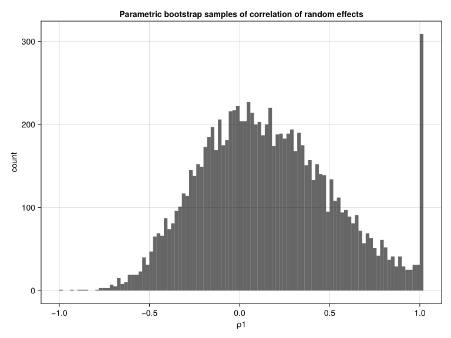

```julia
plt = data(tblsleep) * mapping(:ρ1) * AoG.histogram(;bins=100)
draw(plt; axis=(;title="Parametric bootstrap samples of correlation of random effects"))
```

or, as a count,

```julia
count(tblsleep.ρ1  .≈ 1)
```

```
309
```

```julia
count(tblsleep.ρ1 .≈ -1)
```

```
0
```

Furthermore there are even a few cases where the estimate of the standard deviation of the random effect for the intercept is zero.

```julia
count(tblsleep.σ1 .≈ 0)
```

```
4
```

There is a general condition to check for singularity of an estimated covariance matrix or matrices in a bootstrap sample. The parameter optimized in the estimation is `θ`, the relative covariance parameter. Some of the elements of this parameter vector must be non-negative and, when one of these components is approximately zero, one of the covariance matrices will be singular.

The `issingular` method for a `MixedModel` object that tests if a parameter vector `θ` corresponds to a boundary or singular fit.

This operation is encapsulated in a method for the `issingular` function that works on `MixedModelBootstrap` objects.

```julia
count(issingular(sampsleep))
```

```
313
```

# 5 References

Kronmüller, E., & Barr, D. J. (2007). Perspective-free pragmatics: Broken precedents and the recovery-from-preemption hypothesis. *Journal of Memory and Language*, *56*(3), 436–455. https://doi.org/10.1016/j.jml.2006.05.002

*This page was rendered from git revision [1a894e8](https://github.com/RePsychLing/SMLP2025/tree/1a894e8  
) using Quarto 1.7.29.*

Back to top